# B3_2: Extending models — SEIR, demography & time-varying parameters

## B3_2: Extending models — SEIR, demography & time-varying parameters

Coding compartmental models with R and odin

Swapnil Mishra (Asst. Professor)

Session book: notes, exercises and solutions

## Recap of lecture 1

- odin models are equations, not code — compiled to C once, then fast to run
- `odin::odin({...})` returns a generator; `generator$new(pars...)` creates an instance; `$run(t)` integrates it
- Scenarios are repeated `$new()` calls with different parameters
- Add a `deriv()` line for derived quantities (e.g. cumulative incidence)

Today: grow the SIR skeleton — latent periods, population dynamics and parameters that change over time.

## Adding a latent period: SEIR

For many infections people are exposed but not yet infectious — a latent period. Add an Exposed compartment $E$; exposed people become infectious at rate $\sigma$ (so $1/\sigma$ is the mean latent period):

$$\frac{dS}{dt} = -\beta SI, \quad
\frac{dE}{dt} = \beta SI - \sigma E, \quad
\frac{dI}{dt} = \sigma E - \gamma I, \quad
\frac{dR}{dt} = \gamma I$$

## SEIR in odin

In odin this means one more compartment and re-routing the flows:

```r
seir_generator <- odin::odin({
  deriv(S) <- -beta * S * I
  deriv(E) <- beta * S * I - sigma * E
  deriv(I) <- sigma * E - gamma * I
  deriv(R) <- gamma * I
  initial(S) <- N0 - I0
  initial(E) <- 0
  initial(I) <- I0
  initial(R) <- 0
  N0    <- user(1000)
  I0    <- user(1)
  beta  <- user(2e-4)  # R0 = beta * N / gamma = 2
  gamma <- user(0.1)   # infectious period 10 days
  sigma <- user(0.25)  # latent period 4 days
})
```

[output not shown]

## SEIR dynamics

```r
out_seir <- seir_generator$new()$run(times)
as.data.frame(out_seir) |>
  pivot_longer(cols = c(S, E, I, R),
               names_to = "compartment", values_to = "n") |>
  ggplot(aes(x = t, y = n, colour = compartment)) +
  geom_line(linewidth = 1) +
  scale_colour_manual(values = c(S = "#0072B2", E = "#E69F00",
                                 I = "#D55E00", R = "#009E73")) +
  labs(x = "Time (days)", y = "Number of people", colour = NULL) +
  theme_classic(base_size = 16) +
  theme(legend.position = "bottom")
```

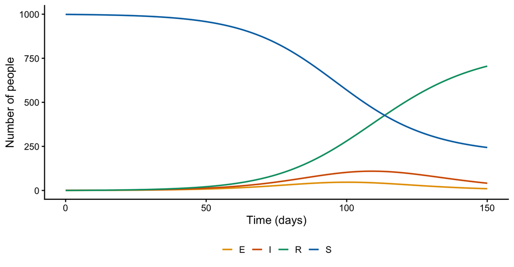

## SEIR vs SIR

Compared with the SIR from lecture 1, the same $R_0 = \beta N / \gamma$ now gives a later, broader peak — the latent period slows the epidemic down even though it does not change $R_0$. Rather than take that on trust, plot both:

```r
sir_generator <- odin::odin({
  deriv(S) <- -beta * S * I
  deriv(I) <- beta * S * I - gamma * I
  deriv(R) <- gamma * I
  initial(S) <- N0 - I0
  initial(I) <- I0
  initial(R) <- 0
  N0    <- user(1000)
  I0    <- user(1)
  beta  <- user(2e-4)
  gamma <- user(0.1)
})
```

[output not shown]

```r
out_sir <- sir_generator$new()$run(times)   # plain SIR for comparison
```

## SEIR vs SIR: the comparison

```r
bind_rows(
  tibble(t = times, I = out_sir[, "I"],  model = "SIR"),
  tibble(t = times, I = out_seir[, "I"], model = "SEIR (4-day latent period)")
) |>
  ggplot(aes(x = t, y = I, colour = model)) +
  geom_line(linewidth = 1) +
  scale_colour_manual(limits = c("SIR", "SEIR (4-day latent period)"),
                      values = c("SIR" = "grey60",
                                 "SEIR (4-day latent period)" = "#D55E00")) +
  labs(x = "Time (days)", y = "Infectious (I)", colour = NULL) +
  theme_classic(base_size = 16) +
  theme(legend.position = "bottom")
```

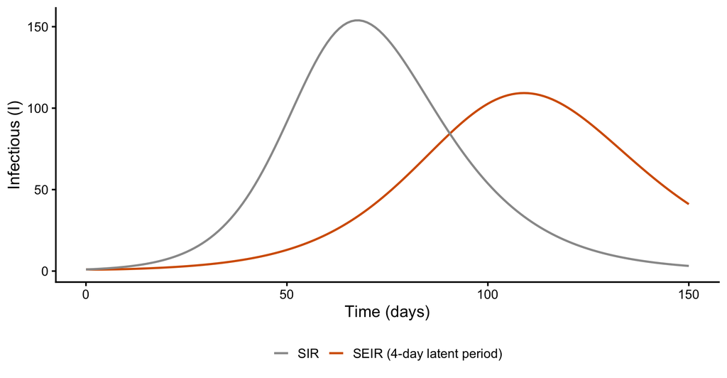

Same total transmission, spread over a longer time: later, lower peak.

## Births and deaths: demography

So far the epidemic is a one-off: everyone ends up in $R$ and nothing else happens.

Over longer horizons, births replenish the susceptible pool. Add a per-capita birth/death rate $\mu$:

- births enter $S$
- deaths leave every compartment at rate $\mu$
- $N$ stays constant
- we now need $N = S + E + I + R$ explicitly for the birth term

We use fast turnover (mean 2 years in the population — think nursery or boarding school) so the long-term behaviour shows on a short horizon.

## Demography in odin

```r
seir_demo <- odin::odin({
  deriv(S) <- mu * N - beta * S * I - mu * S
  deriv(E) <- beta * S * I - sigma * E - mu * E
  deriv(I) <- sigma * E - gamma * I - mu * I
  deriv(R) <- gamma * I - mu * R
  N <- S + E + I + R
  initial(S) <- N0 - I0
  initial(E) <- 0
  initial(I) <- I0
  initial(R) <- 0
  N0    <- user(1000)
  I0    <- user(1)
  beta  <- user(2e-4)
  gamma <- user(0.1)
  sigma <- user(0.25)
  mu    <- user(1 / (2 * 365))  # mean 2 years in the population
})
```

[output not shown]

## Endemic equilibrium

```r
times_long <- seq(0, 365 * 20, by = 7)   # 20 years, weekly output
out_demo <- seir_demo$new()$run(times_long)
tibble(t = out_demo[, "t"] / 365, I = out_demo[, "I"]) |>
  ggplot(aes(x = t, y = I)) +
  geom_line(linewidth = 1, colour = "#D55E00") +
  coord_cartesian(xlim = c(0, 10)) +
  labs(x = "Time (years)", y = "Infectious (I)") +
  theme_classic(base_size = 16)
```

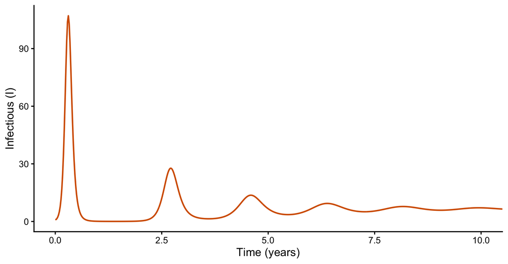

Instead of dying out after one wave, incidence oscillates with shrinking amplitude and settles to an endemic equilibrium — newborn susceptibles keep transmission going.

## Time-varying parameters

So far every parameter has been fixed for the whole run. Real drivers change over time:

- transmission rises in winter and falls in summer
- it can shift abruptly when behaviour changes

The solver needs parameter values at arbitrary times — not just at the times you have data for — so odin takes a time series of values from you and builds a continuous function from it with `interpolate()`.

Two examples first, then the machinery.

## A shift in regime: `constant`

Transmission changes from one level to another at a known time and stays there — two regimes. With `"constant"` interpolation, `beta` holds each knot’s value until the next knot: exactly a step.

```r
sir_step <- odin::odin({
  deriv(S) <- -beta * S * I
  deriv(I) <- beta * S * I - gamma * I
  deriv(R) <- gamma * I
  beta <- interpolate(beta_times, beta_vals, "constant")
  beta_times[] <- user()   # regime change times
  beta_vals[] <- user()    # beta in each regime
  dim(beta_times) <- user()
  dim(beta_vals) <- user()
  initial(S) <- N0 - I0
  initial(I) <- I0
  initial(R) <- 0
  N0    <- user(1000)
  I0    <- user(1)
  gamma <- user(0.1)
})
```

[output not shown]

## A shift in regime: forcing

```r
## two regimes: beta halves at day 40
beta_times <- c(0, 40, 150)
beta_vals  <- c(2e-4, 1e-4, 1e-4)
tibble(t = beta_times, beta = beta_vals) |>
  ggplot(aes(x = t, y = beta)) +
  geom_step(linewidth = 1) +
  coord_cartesian(xlim = range(times)) +
  labs(x = "Time (days)", y = expression(beta)) +
  theme_classic(base_size = 16)
```

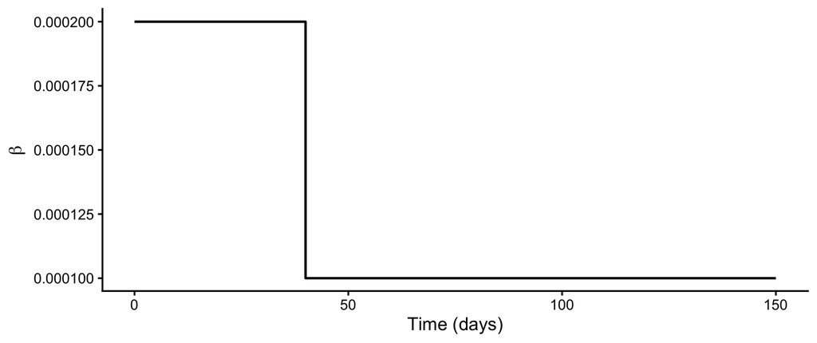

Always plot what you are feeding in, before running.

## A shift in regime: epidemic curve

```r
out_step   <- sir_step$new(beta_times = beta_times,
                           beta_vals = beta_vals)$run(times)
out_nostep <- sir_generator$new()$run(times)   # baseline: constant beta
bind_rows(
  tibble(t = times, I = out_nostep[, "I"], scenario = "constant beta"),
  tibble(t = times, I = out_step[, "I"],   scenario = "beta halves at day 40")
) |>
  ggplot(aes(x = t, y = I, colour = scenario)) +
  geom_line(linewidth = 1) +
  geom_vline(xintercept = 40, linetype = "dashed") +
  scale_colour_manual(limits = c("constant beta", "beta halves at day 40"),
                      values = c("constant beta" = "grey60",
                                 "beta halves at day 40" = "#D55E00")) +
  labs(x = "Time (days)", y = "Infectious (I)", colour = NULL) +
  theme_classic(base_size = 16) +
  theme(legend.position = "bottom")
```

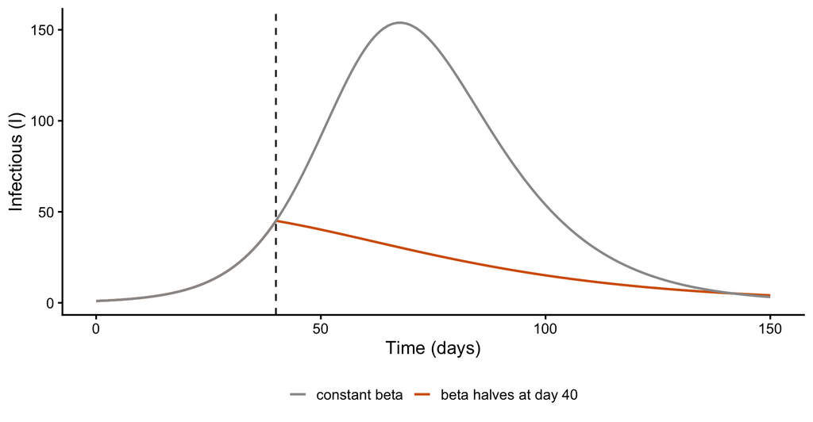

One compiled model; the time series is just another parameter at `$new()`.

## Seasonal forcing: `"linear"`

A step is the wrong shape for smooth drivers like seasonality. And a practical point: in the closed models so far, one wave ends transmission — nothing left for seasonality to act on. So we let immunity wane (SIRS: recovered return to $S$ at rate $\omega$, mean immunity 90 days):

```r
sirs_seasonal <- odin::odin({
  deriv(S) <- -beta * S * I + omega * R
  deriv(I) <- beta * S * I - gamma * I
  deriv(R) <- gamma * I - omega * R
  beta <- interpolate(beta_times, beta_vals, "linear")
  beta_times[] <- user()   # time points
  beta_vals[] <- user()    # beta at each time point
  dim(beta_times) <- user()
  dim(beta_vals) <- user()
  initial(S) <- N0 - I0
  initial(I) <- I0
  initial(R) <- 0
  N0    <- user(1000)
  I0    <- user(1)
  gamma <- user(0.1)    # infectious period 10 days
  omega <- user(1 / 90) # immunity lasts 90 days on average
})
```

[output not shown]

## The forcing series

Monthly values over five years, peaking in “winter”:

```r
t_years <- 5
beta_times <- seq(0, 365 * t_years, by = 365 / 12)   # monthly knots
beta_vals  <- 2e-4 * (1 + 0.3 * cos(2 * pi * beta_times / 365))
```

Always plot the series you feed into a model, before running anything.

## The forcing series, plotted

```r
tibble(t = beta_times / 365, beta = beta_vals) |>
  ggplot(aes(x = t, y = beta)) +
  geom_line() +
  geom_point(shape = 16, size = 0.8) +
  labs(x = "Time (years)", y = expression(beta)) +
  theme_classic(base_size = 16)
```

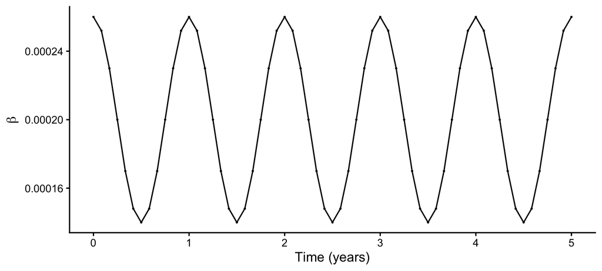

## Seasonal waves

Then pass the vectors at `$new()`; odin infers their lengths:

```r
mod <- sirs_seasonal$new(beta_times = beta_times, beta_vals = beta_vals)
times_seas <- seq(0, 365 * t_years, by = 1)   # daily output over 5 years
out_seas <- mod$run(times_seas)
```

```r
tibble(t = times_seas / 365, I = out_seas[, "I"]) |>
  ggplot(aes(x = t, y = I)) +
  geom_line(linewidth = 0.75, colour = "#D55E00") +
  labs(x = "Time (years)", y = "Infectious (I)") +
  theme_classic(base_size = 16)
```

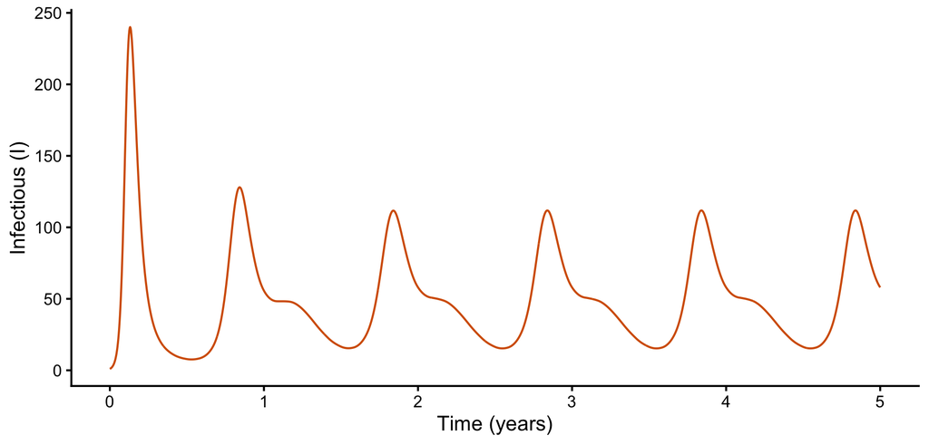

## What `interpolate()` is doing

- The solver evaluates the equations at whatever times its internal steps require — not just at your monthly knots
- `interpolate(beta_times, beta_vals, type)` turns your points into a continuous `beta(t)`; `type` decides what happens *between* the knots
- `"constant"` — steps; for quantities that change in jumps
- `"linear"` — joins the dots; good default for smooth drivers
- `"spline"` — smooth curve; can overshoot between widely spaced knots
- `dim(beta_times) <- user()` cannot be left out: odin compiles the model before it sees any data, so every array needs a declared size at compile time — “user” means the length is fixed at `$new()`, where odin infers it from the vectors you pass

## The three interpolation types

```r
knot_times <- seq(0, 365, by = 365 / 4)   # quarterly knots — wider apart on purpose
knot_vals  <- 2e-4 * (1 + 0.3 * cos(2 * pi * knot_times / 365))
days       <- seq(0, 365, by = 1)   # daily points to evaluate the curves on

beta_spline   <- spline(knot_times, knot_vals, xout = days)$y                     # "spline"
beta_linear   <- approx(knot_times, knot_vals, xout = days, method = "linear")$y  # "linear"
beta_constant <- approx(knot_times, knot_vals, xout = days, method = "constant")$y # "constant"
```

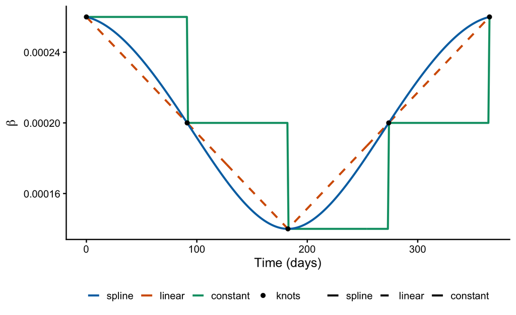

## Exercise 2.1 — A less variable latent period

A single $E$ compartment implies an exponential latent period: the most likely outcome is becoming infectious *immediately*, with a long tail — variance equals the mean squared. Real latent periods cluster around the mean, so we want **less** variability, not more:

- Chain two exposed compartments $E_1 \to E_2$, each progressing at rate `2 * sigma`
- The mean latent period stays `1/sigma`, but the variance is halved (an Erlang distribution)

Build this model, run it with `sigma = 1/8` next to the single-$E$ version, and compare the epidemic curves.

## Exercise 2.2 — Disease-induced mortality

Extend the demography model (`seir_demo`) so that infectious people die at an additional rate `delta` (disease-induced mortality):

- Deaths accumulate in a new compartment `D` (`deriv(D) <- delta * I`)
- The living population is no longer constant

Run 20 years with `delta = 0` and `delta = 0.01`, and plot the total population size over time (compute it in R with `rowSums` on the compartment columns), with the y-axis starting at 0. What happens? And what goes wrong if you let R choose the axis limits?

## Recap

- New compartments = new `deriv()` + `initial()` lines, and re-routing flows
- Births and deaths turn a single epidemic into endemic dynamics
- One generator, many `$new()` calls: the scenario workflow
- Time-varying parameters: `interpolate()` drives a parameter from a user-supplied time series — plot the series first, then let odin infer the array lengths

**Back to:** B3_1 slides: odin basics & the SIR model

Session book: notes, exercises and solutions